# Assignment 12: Predictive Modeling - Part 3

*How to do it?*:

- Open the Rmarkdown file of this assignment (link) in Rstudio.
- Right under each **question**, insert a code chunk (you can use the hotkey `Ctrl + Alt + I` to add a code chunk) and code the solution for the question.
- `Knit` the rmarkdown file (hotkey: `Ctrl + Alt + K`) to export an html.
- Publish the html file to your Githiub Page.

*Submission*: Submit the link on Github of the assignment to Blackboard.

1. Use the `PimaIndiansDiabetes` dataset. Use 15% data for testing. Use cross-validation with of 7 folds to tune random forest `(method='ranger')`. What are the parameters that produce the greatest accuracy? What is the testing accuracy.

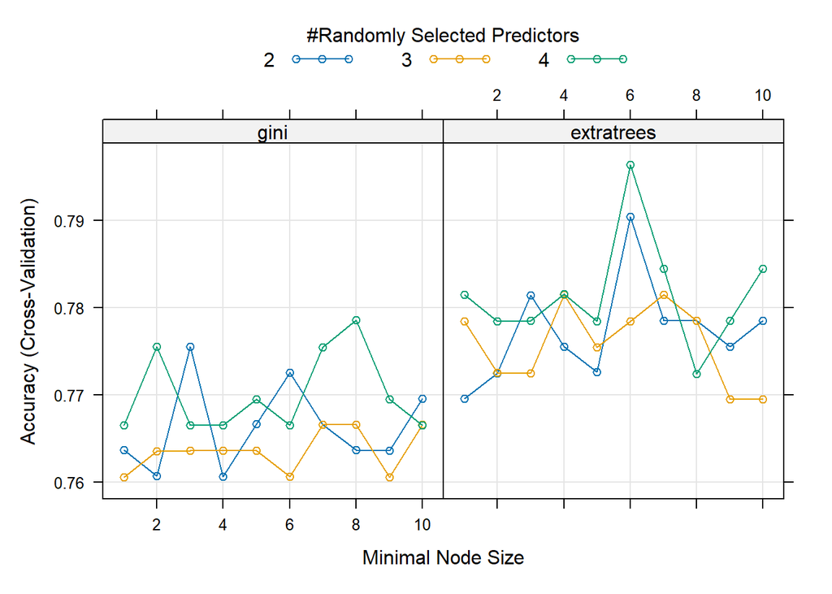

```r
####################### Calling Libraries and Creating Data Frames #######################
# Calling libraries
library(mlbench)
library(tidyverse)
library(caret)

# Importing data
data(PimaIndiansDiabetes)
df <- tibble(PimaIndiansDiabetes)

# Creating second df to handle second approach to handle missing data
df2 <- tibble(PimaIndiansDiabetes)


################################# Cleaning Data ##########################################
# All columns seem relevant to analysis and therefore do not need to be removed

# Setting the target variable
df <- df %>% rename(target=diabetes)
df2 <- df2 %>% rename(target=diabetes)

# Only need to convert target variable to factor because all other variables are numeric (none are categorical)
df <- df %>% mutate(target = as.factor(target))
df2 <- df2 %>% mutate(target = as.factor(target))

# Under assumption that 0s in the data represent missing data because for example having a diastolic blood pressure of 0 means that that person is dead. To handle these missing values, we will compare two approaches: first, getting rid of any rows that have 0s (missing data); and second, imputing these missing values with the averages of the non-missing data

# Approach 1: Treating 0s in df as NAs and removing these rows

# Converting 0 values to NAs in columns in which 0 is not a reasonably possible value
df$glucose <- na_if(df$glucose, 0)
df$pressure <- na_if(df$pressure, 0)
df$triceps <- na_if(df$triceps, 0)
df$insulin <- na_if(df$insulin, 0)
df$mass <- na_if(df$mass, 0)

# Dropping rows with NA values
df = drop_na(df)

# Approach 2: Imputing 0s in df with averages of non-zero values

# Converting 0 values to NAs in columns in which 0 is not a reasonably possible value
df2$glucose <- na_if(df2$glucose, 0)
df2$pressure <- na_if(df2$pressure, 0)
df2$triceps <- na_if(df2$triceps, 0)
df2$insulin <- na_if(df2$insulin, 0)
df2$mass <- na_if(df2$mass, 0)

# Imputing the mean of the non-missing data for these NA values
df2$glucose[is.na(df2$glucose)] = mean(df2$glucose, na.rm = TRUE)
df2$pressure[is.na(df2$pressure)] = mean(df2$pressure, na.rm = TRUE)
df2$triceps[is.na(df2$triceps)] = mean(df2$triceps, na.rm = TRUE)
df2$insulin[is.na(df2$insulin)] = mean(df2$insulin, na.rm = TRUE)
df2$mass[is.na(df2$mass)] = mean(df2$mass, na.rm = TRUE)

####################### Splitting Data into Training and Testing #########################
set.seed(2020)
splitIndex <- createDataPartition(df$target, p = .85, list = FALSE)

df_train <- df[splitIndex,]
df_test <- df[-splitIndex,]

splitIndex2 <- createDataPartition(df2$target, p = .85, list = FALSE)

df2_train <- df2[splitIndex2,]
df2_test <- df2[-splitIndex2,]

################################## Tuning Random Forests #################################
# Training and testing random forest 1 (removed NA rows)
trControl = trainControl(method = "cv", number = 7)
tuneGrid = expand.grid(mtry = 2:4,
                       splitrule = c('gini', 'extratrees'),
                       min.node.size = c(1:10))

forest1 <- train(target~., data=df_train, method = "ranger", trControl = trControl, tuneGrid = tuneGrid)

plot(forest1)
```

```r
forest_1_pred <- predict(forest1, df_test)

forest_1_cm <- confusionMatrix(data=forest_1_pred, reference = df_test$target)

forest_1_cm$overall[1]
```

```
##  Accuracy
## 0.7413793
```

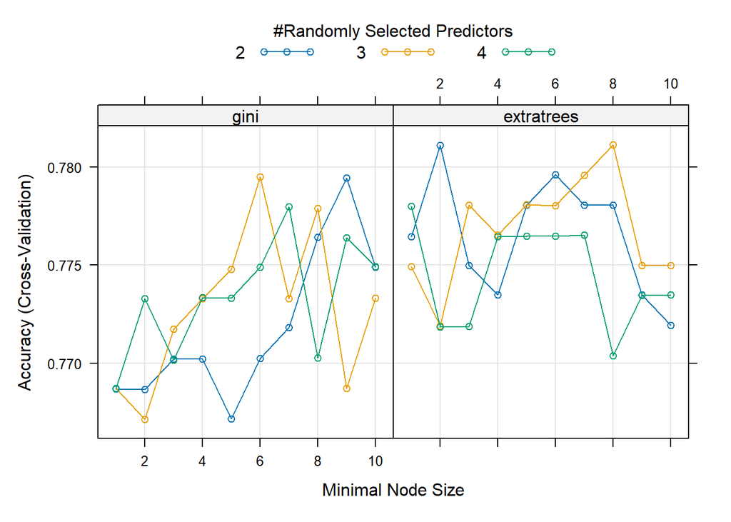

```r
# Training and testing random forest 2 (imputed NAs with mean)
forest2 <- train(target~., data = df2_train, method = "ranger", trControl = trControl, tuneGrid = tuneGrid)

plot(forest2)
```

```r
forest_2_pred <- predict(forest2, df2_test)

forest_2_cm <-confusionMatrix(data = forest_2_pred, reference = df2_test$target)

forest_2_cm$overall[1]
```

```
##  Accuracy
## 0.7043478
```

```r
# For the first forest, the parameters that create the highest accuracy are a minimum node size of 6 and using the extratrees algorithm with 4 randomly selected predictors. These parameters generate a testing accuracy of roughly 74.14%. For the second forest, the parameters that yield the highest accuracy are a minimum node size of 2 and using the extratrees algorithm with 2 randomly selected predictors. These parameters generate a testing accuracy of roughly 70.43%.
```

2. Use the `PimaIndiansDiabetes` dataset. Go to https://topepo.github.io/caret/available-models.html and pick a classification model. Tune the classification model using cross-validation of 7 folds.

```r
# Training and testing LDA 1 (removed NA rows)

lda1 <- train(target~., data=df_train, method = "lda", trControl = trControl)

lda_1_pred <- predict(lda1, df_test)

lda_1_cm <- confusionMatrix(data=lda_1_pred, reference = df_test$target)

lda_1_cm$overall[1]
```

```
##  Accuracy
## 0.7068966
```

```r
# Training and testing random forest 2 (imputed NAs with mean)
lda2 <- train(target~., data = df2_train, method = "lda", trControl = trControl)

lda_2_pred <- predict(lda2, df2_test)

lda_2_cm <-confusionMatrix(data = lda_2_pred, reference = df2_test$target)

lda_2_cm$overall[1]
```

```
##  Accuracy
## 0.7130435
```

3. (Model Comparison) Use the `PimaIndiansDiabetes` dataset. Pick two models at [this link](https://topepo.github.io/caret/available-models.html) to compare using 7-fold cross validation method. Evaluate the accuracy of the final model on the test data.

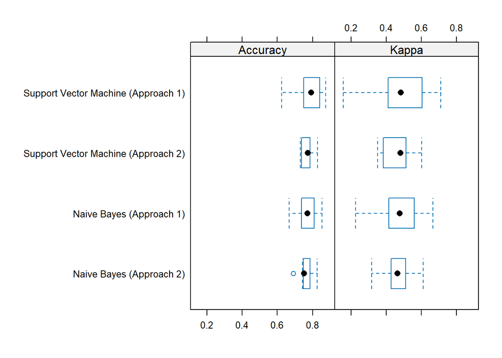

```r
# Models using the first df (removing missing values)
nb1 <- train(target~., data=df_train, method = "naive_bayes", trControl = trControl)

svm1 <- train(target~., data=df_train, method = "svmLinear", trControl = trControl)

# Models using the second df (imputing missing values with means)
nb2 <- train(target~., data=df2_train, method = "naive_bayes", trControl = trControl)

svm2 <- train(target~., data=df2_train, method = "svmLinear", trControl = trControl)

results <- resamples(list('Naive Bayes (Approach 1)' = nb1,
                          'Naive Bayes (Approach 2)' = nb2,
                          'Support Vector Machine (Approach 1)' = svm1,
                          'Support Vector Machine (Approach 2)' = svm2))
bwplot(results)
```

```r
# All of the models appear to be fairly close in terms of accuracy, however I would argue that the Support Vector Machine (Approach 1) model is the best due to the fact that the upper 50% of its accuracy scores is the highest among all of the models.

# Given this, I will now evaluate the accuracy of the Support Vector Machine (Approach 1) model on the testing data
svm1_pred <- predict(svm1, df_test)
svm1_cm <- confusionMatrix(data = svm1_pred, reference = df_test$target)
svm1_cm$overall[1]
```

```
##  Accuracy
## 0.7241379
```